# Table of Content

- 1. Template Literal
- 2. Destructuring Objects
- 3. Destructuring Arrays
- 4. Object Literal
- 5. For of Loop
- 6. Spread Operator
- 7. Rest Operator
- 8. Arrow Functions
- 9. Default Params
- 10. includes()
- 11. Let & Const
  - var
  - let
  - const
- 12. Import & Export
- 13. padStart() & padEnd()
- 14. Classes
- 15. Promises
- 16. Fetch
- 16. Async & Await
- 17. Sets
- Credit

# 1. Template Literal

**Example 1: how to print out multiple line (the old way)**

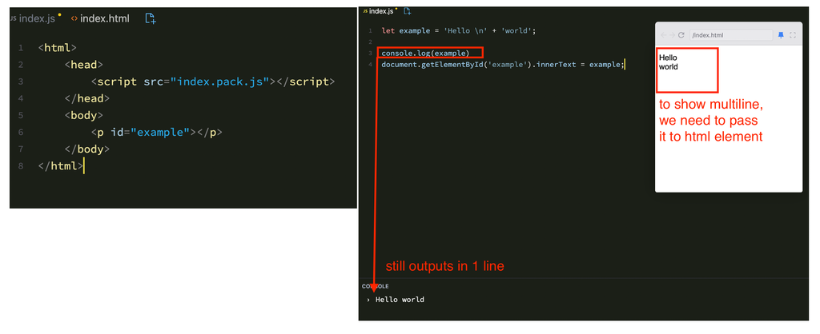

**Example 2: how to print out multiple line (using template literals)**

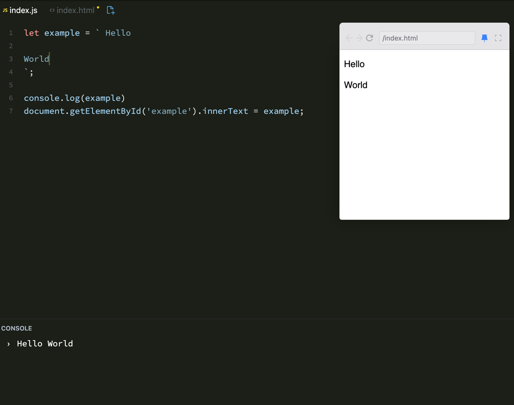

# 2. Destructuring Objects

```python
%%script node


const player = {
  name: 'Lebron James',
  club: 'LA Lakers',
  address: {
    city: 'Los Angeles'
  }
};

// Getting values, the old way
console.log( player.address.city );
```

```
Los Angeles
```

```python
%%script node

const player = {
  name: 'Lebron James',
  club: 'LA Lakers',
  address: {
    city: 'Los Angeles'
  }
};


// Getting values, using object destructuring
const {name, club, address:{ city } } = player;

console.log('name:', name);
console.log('club:', club);
console.log('city:', city);
console.log('address', address) // this is error because we do not save `address` to a const
```

[output not shown]

- The old way to get value from an object is using `object.key` syntax.
- The new way is to destructure the object. Eg `const {key1, key2, key3: {nestedKey1} } = object`
  - now, we can use `[key1, key2, nestedKey1]` as normal variable

# 3. Destructuring Arrays

- We can destructure array similar to how we would do an object. The difference is now, we use `[]` instead of `{}`.
- The syntax is: `let [elem1, elem2, elemN] = array`
- What will happen is that the variable we destructure each of the elements into is actually a pointer, pointing to the index of the array.
- So, in the example above, `elem1` is a pointer pointing to the first index of the array, ie `array[0]`.
  - `elem2` is a pointer pointing to `array[1]` and so on.

```python
%%script node

// desctruturing an array
author = ['Jane', 'Eyre', 'Rochester']
let [firstName, middleName, lastName] = author

console.log('firstName:', firstName)
console.log('middleName:', middleName)
console.log('lastName:', lastName)
```

```
firstName: Jane
middleName: Eyre
lastName: Rochester
```

# 4. Object Literal

- When creating an object with value having the same name as the variable name of the object, we can omit writing the key.
- For example, say we store a value in variable called `city` and we want to create an object with key `city`.
  - The old way of doing this (see example 1): `{city: city}`
  - The new way of doing this (see example 2): `{city}`
  - Both give the same result.

```python
%%script node


function addressMaker(city, state) {

    // Example 1: old way
    const newAddress = {city: city, state: state}
    console.log(newAddress)
}

addressMaker('Austin', 'Texas');
```

```
{ city: 'Austin', state: 'Texas' }
```

```python
%%script node

function addressMaker(city, state) {

    // Example 2: using object literal
    const newAddress = {city, state}
    console.log(newAddress)
}

addressMaker('Austin', 'Texas');
```

```
{ city: 'Austin', state: 'Texas' }
```

# 5. For of Loop

```python
%%script node

let incomes = [62000, 67000, 75000];
let total = 0;

for (const income of incomes) {
    console.log(income);
    total += income;
}

console.log('total:', total)
```

```
62000
67000
75000
total: 204000
```

```python
%%script node
const students = [
    { name: "John", city: "New York" },
    { name: "Peter", city: "Paris"},
    { name: "Kate", city: "Sidney" }
]

for (const stu of students) {
    // destructuring object
    const {name, city} = stu;
    console.log(`${name} lives in ${city}`)
}
```

```
John lives in New York
Peter lives in Paris
Kate lives in Sidney
```

# 6. Spread Operator

- We can use spread operator to make copy of an iterable.
- To make a copy of an array, we use syntaxt `[ ...array ]`
- We can also add something to the array we are copying while using the spread operator.
  - To add to the front of the copied array before the entire content of the array we are copying, we use: `[ newElem, ...array]`
  - To add to the end, we do: `[...array, newElem]`
  - So, the general syntax is just same as we would building an array, separate each element by a comma `,`.
  - I think it is easier to think of JS spread operator as list concatenation in python.

```
(See example below)
// JS
myNewArray = [ newElem, ...array, newElem ]

// python equivalent
myNewArray = [newElem] + array + [newElem]
```

- We can also use spread operator with objects. The syntax is the same, but instead of it be within a `[]`, we do it in a `{}`. See last example below.

**Code Example 1: Python equivalent of spread operator is list concatenation**

```python
oldArray = ['Mary', 'Joel', 'Danny']

# this operation create a new array and not a pointer to oldarray
newArray = ["myBoss"] + oldArray + ["myCEO"]
print('newArray:', newArray)

# note that this latest addition is not in the newArray
oldArray.append('myNeighbor')
print('newArray:', newArray)
```

```
newArray: ['myBoss', 'Mary', 'Joel', 'Danny', 'myCEO']
newArray: ['myBoss', 'Mary', 'Joel', 'Danny', 'myCEO']
```

**Code Example 2: We can achieve the same as above using spread operator in JS**

```python
%%script node

let oldArray = ['Mary', 'Joel', 'Danny'];

// this operation create a new array and not a pointer to oldarray
let newArray = ["myBoss", ...oldArray, "myCEO"]

console.log('newArray:', newArray)

// note that this latest addition is not in the newArray
oldArray.push('myNeighbor')
console.log('newArray:', newArray)
```

```
newArray: [ 'myBoss', 'Mary', 'Joel', 'Danny', 'myCEO' ]
newArray: [ 'myBoss', 'Mary', 'Joel', 'Danny', 'myCEO' ]
```

**Code Example 3: Directly refer to the array does not create a copy but only a pointer to the array**

```python
%%script node

let contacts = ['Mary', 'Joel', 'Danny'];

// this does not create a copy
// but a pointer to the other array
let personalFriends = contacts;

console.log('personalFriends:', personalFriends)
contacts.push('myBoss');

// we can confirm that this is a pointer
// because the latest push is also added
console.log('personalFriends:', personalFriends)
```

```
personalFriends: [ 'Mary', 'Joel', 'Danny' ]
personalFriends: [ 'Mary', 'Joel', 'Danny', 'myBoss' ]
```

**Code Example 4: Using spread operator on array `[...array]` creates a copy**

```python
%%script node

let contacts = ['Mary', 'Joel', 'Danny'];

// this creates a copy of the `contacts` array
let personalFriends = [ ...contacts ];

console.log('personalFriends:', personalFriends)
contacts.push('myBoss');

// we can confirm that this is a copy
// because the latest push is not added
console.log('personalFriends:', personalFriends)
```

```
personalFriends: [ 'Mary', 'Joel', 'Danny' ]
personalFriends: [ 'Mary', 'Joel', 'Danny' ]
```

**Code Example 5: Using spread operator on an object creates a copy of that object**

```python
%%script node

let person = {
    name: "Adam",
    age: 25,
    city: "New York"
}

let employee = {

    // this copies from th eobject person
    ...person,
    salary: 50000,
    position: "Software Developer"
}


console.log('employee:', employee)

// adding new key value pair
person['hobby'] = "Climbing Mount Everest"
console.log('person:', person)

// note that the latest keyvalue pair we added to person is not in employee
// which is what we'd expect
console.log('employee:', employee)
```

```
employee: {
  name: 'Adam',
  age: 25,
  city: 'New York',
  salary: 50000,
  position: 'Software Developer'
}
person: {
  name: 'Adam',
  age: 25,
  city: 'New York',
  hobby: 'Climbing Mount Everest'
}
employee: {
  name: 'Adam',
  age: 25,
  city: 'New York',
  salary: 50000,
  position: 'Software Developer'
}
```

# 7. Rest Operator

- We use rest operator when we don't know how many arguments we will have as input to our functions.

```python
%%script node

// 1. this is good for a single arg input

function add1(nums) {
    console.log(nums)
}

add1(4) // 4

// -------------------------------------------------
// 2. but what if we need to take in multiple inputs?
// we can use `arguments`, but it is not an array (not iterable)

function add2(nums) {
    console.log(arguments); // now deprecated unofficially
}

add2(4,5,6,7) // { '0': 4, '1': 5, '2': 6, '3': 7}


// -------------------------------------------------
// 3. This is when we use rest operator
// we will get an array

function add3(...nums) {
    console.log(nums)
}

add3(4,5,6,7) // [4, 5, 6, 7]
```

```
4
[Arguments] { '0': 4, '1': 5, '2': 6, '3': 7 }
[ 4, 5, 6, 7 ]
```

# 8. Arrow Functions

- We can write functions in 3 different ways in JS.

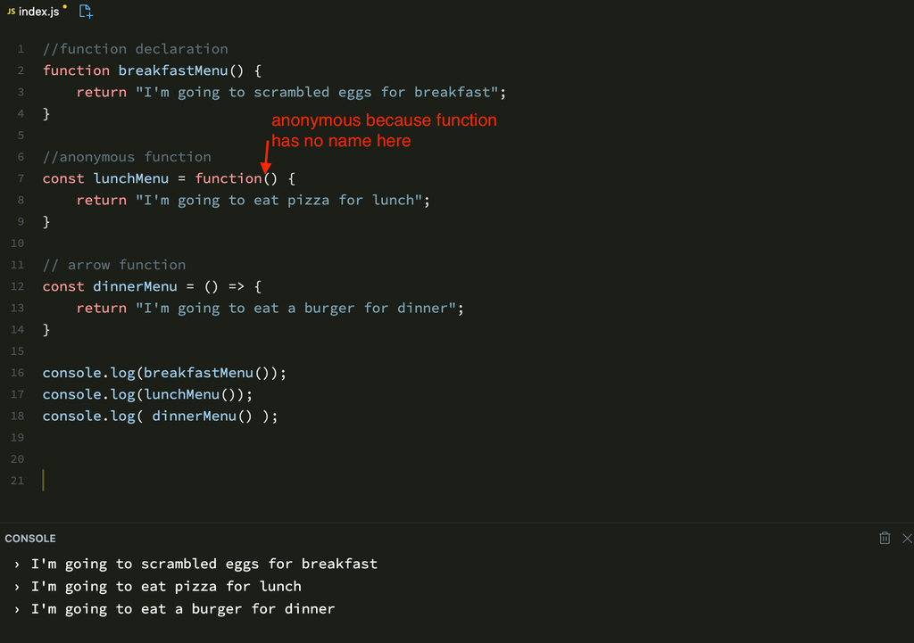

**Code Example 1: Different ways of writing arrow functions**

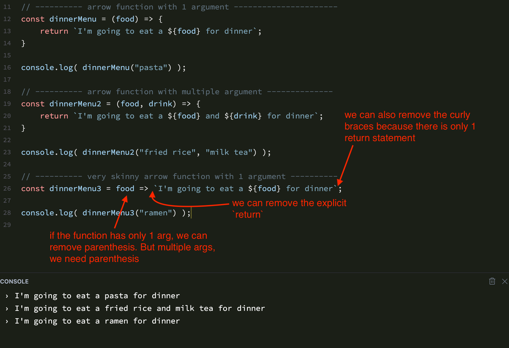

# 9. Default Params

- This is the same as in Python. See example below for syntax.

```python
%%script node

const myFavFood = (food = "Tom Yam") => {
    console.log(`My favorite food is ${food}.`);
}

myFavFood()
myFavFood("Ramen")
```

```
My favorite food is Tom Yam.
My favorite food is Ramen.
```

# 10. includes()

- We use this to check if some value exist in an array.
- This is similar to `x in list` in Python. It also returns a boolean.
- Not supported by Internet Explorer.

```python
5 in [1,2,3,4]
```

```
False
```

```python
%%script node
console.log([1,2,3,4].includes(5))
```

```
false
```

# 11. Let & Const

### var

- Variable hoisting: var is hoisted out into the outer scope.
  - We can see this in action in Code Example 1 below -- we are actually declaring and defining `example` variable in line 4 within the if statement but essentially what the javascript see is similar to Code Example 2 below where `var example` is hoisted out to line 3 before the if statement.

**Code Example 1: Var variable is hoisted into the outer scope**

```python
%%script node

if (false) {
    var example = 5
}

// this should be an error but we only get undefined
// because of variable hoisting
console.log(example)
```

```
undefined
```

**Code Example 2: What JS essentially see (var is hoisted out into the outer scope)**

```python
%%script node

var example;

if (false) {
    example = 5
}

console.log(example)
```

```
undefined
```

### let

- To workaround variable hoisting, we use `let` and `const`.
- `let` is a stricter version of variable and it uses block scope.
- If we try to recreate the above Code Example 1 using `let`, we will get error because the `let example` variable only exist within the if statement, and not out of it.
  - This is as we'd expected, because the way Javascript now sees it is essentially how we had written it.

**Code Example 3: let variable only exist within the block it is defined in**

```python
%%script node

if (false) {
    // example variable only exist here within this nested block of code
    let example = 5
}

// we now get an error because let variable does not exist here
console.log(example)
```

```
[stdin]:7
console.log(example)
            ^

ReferenceError: example is not defined
    at [stdin]:7:13
    at runScriptInThisContext (node:internal/vm:209:10)
    at node:internal/process/execution:118:14
    at [stdin]-wrapper:6:24
    at runScript (node:internal/process/execution:101:62)
    at evalScript (node:internal/process/execution:136:3)
    at node:internal/main/eval_stdin:32:5
    at Socket.<anonymous> (node:internal/process/execution:237:5)
    at Socket.emit (node:events:530:35)
    at endReadableNT (node:internal/streams/readable:1698:12)

Node.js v22.11.0
```

[output not shown]

### const

- `const` stands for constant.
- When set to primitive datatype (number, string, boolean), you can not change it.
- However, when set to arrays, and object, you can still "make changes" to it. We just can't completely change it to something else;

**Code Example 4: changing data stored in const variable**

```python
%%script node

const myNum = 5;
// myNum = 10 // TypeError: Assignment to constant variable.

const obj = {}
obj['food'] = 'Tom Yam'
console.log(obj) // { food: 'Tom Yam' }

const arr = []
arr.push('Tom Yam')
console.log(arr) // [ 'Tom Yam' ]
```

```
{ food: 'Tom Yam' }
[ 'Tom Yam' ]
```

# 12. Import & Export

- We can now export and import defined stuffs from another script (like we would do with python) in Javascript.
- The syntax for exporting is `export {}`. We place a list of stuffs we want to export inside the curly braces.
- Likewise, to import, we use `import {} from x` where `x` is the script location where we want to import it from. We put a list of stuffs we want to import in the curly braces.

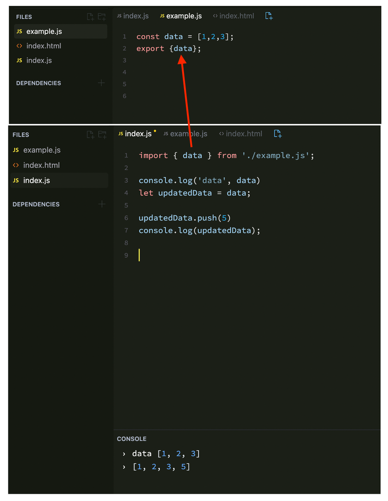

# 13. padStart() & padEnd()

- Padding to start or end of string depending on the length of the string.

```python
%%script node

let example = 'coffee'; // 6 character long
console.log(example)

// 10 - 6 = 4 character of x will be added to start of string
console.log(example.padStart(10,'x'))

// 10 - 6 = 4 character of x will be added to end of string
console.log(example.padEnd(10,'x'))
```

```
coffee
xxxxcoffee
coffeexxxx
```

# 14. Classes

- `this` keyword in Javascript class act like the `self` keyword in Python.

**Code Example 1: Simple class in JS**

```python
%%script node

class Animal {

    constructor(type, legs) {
        this.type = type;
        this.legs = legs

    }

}

let cat = new Animal('Brown Tabby', 4);
console.log(cat)
console.log(cat.type)
console.log(cat.legs)

// we can also reset the value
cat.legs = 3
console.log(cat.legs) // now our sad cat has 3 legs

let robot = new Animal(); // we did not send any args
console.log(robot)
```

```
Animal { type: 'Brown Tabby', legs: 4 }
Brown Tabby
4
3
Animal { type: undefined, legs: undefined }
```

**Code Example 2: Class with method**

```python
%%script node

class Animal {

    constructor(type, legs) {
        this.type = type;
        this.legs = legs

    }

    // define method for this class
    makeNoise(sound = 'Loud Noise') {
        console.log(sound);
    }

}


let cat = new Animal('Brown Tabby', 4)
cat.makeNoise('Meow')
cat.makeNoise()
```

```
Meow
Loud Noise
```

**Code Example 3: Static method within a class allow us to use the method without creating an instance of the class**

```python
%%script node

class Animal {

    constructor(type, legs) {
        this.type = type;
        this.legs = legs

    }

    // static function
    static hiFive() {
        return 'Hi Five!';
    }

}

console.log(Animal.hiFive())
```

```
Hi Five!
```

**Code Example 4: Using getter function in a class**

```python
%%script node

class Animal {

    constructor(type, legs) {
        this.type = type;
        this.legs = legs

    }



    // getter function is treated like a property of our instance
    // ie cant override
    get metaData() {
        return `Type: ${this.type}, Legs: ${this.legs}`
    }


}

let cat = new Animal('Tabby Cat', 4)
console.log(cat.metaData)

// nothing will happen if we try to override getter function
cat.metaData = 'new things'
console.log(cat.metaData)
```

```
Type: Tabby Cat, Legs: 4
Type: Tabby Cat, Legs: 4
```

**Code Example 5: Extending parent class with own constructor + overriding parent's method**

```python
%%script node

class Animal {

    constructor(type, legs) {
        this.type = type;
        this.legs = legs

    }

    makeNoise(sound = 'Loud Noise') {
        console.log(sound)
    }

    get metaData() {
        return `Type: ${this.type}, Legs: ${this.legs}`
    }

}


// extending parent class, with own constructor
class Dog extends Animal {
    constructor(type, legs, fierce) {
        super(type, legs);
        this.fierce = fierce;
    }

    // overriding parent's class method
    makeNoise(sound = 'woof') {
        console.log(sound)
    }
}


let dog = new Dog('Bull Dog', 4, true)
console.log(dog)
dog.makeNoise()

// we can still use method defined in parent's class
console.log(dog.metaData)
```

```
Dog { type: 'Bull Dog', legs: 4, fierce: true }
woof
Type: Bull Dog, Legs: 4
```

# 15. Promises

- Promises usually used on network request eg trying to fetch some data from an API, or they could be used in asynchronous function.
- 3 possible outcome of promises:
  - pending
  - successful
  - rejected
- Promise takes a function. The function takes 2 parameters. Usually the parameters of the function are called `resolve` and `reject` (but we are free to call it anything we want).
  - These `resolve` and `reject` parameters takes in callback functions that will be run:
    - When the promise request is successful, the `resolve` callback function will be run.
    - When the promise request is rejected, the `reject` callback function will be run.

**Example 1: Promises in asynchronous function**

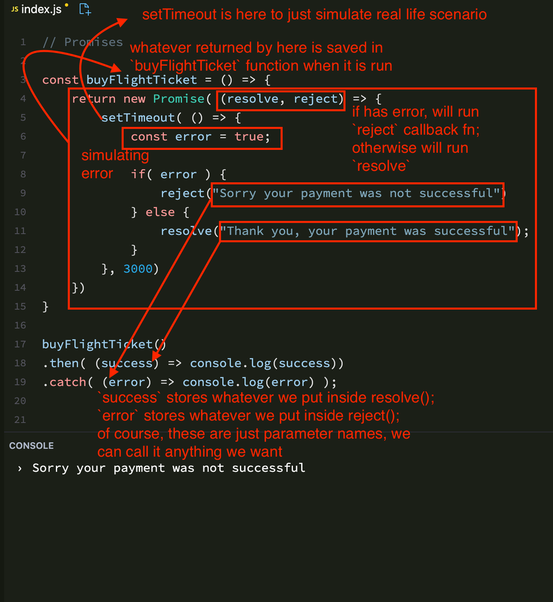

**Code Example 2: Promise with object return value on success**

```python
%%script node

const getUser = () => {
    return new Promise ((resolve, reject) => {

        setTimeout(() => {

            const error = false;

            if(error) {
                reject("Sorry, User 1234 is not found");
            } else {
                resolve({
                    userId: 1234,
                    name: "Lily",
                    tier: "Premium"
                })
            }

        }, 3000)

    })
}

getUser()
.then((data) => {console.log(data)})
.catch((error) => {console.log(error)})
```

```
{ userId: 1234, name: 'Lily', tier: 'Premium' }
```

**Code Example 2: Passing parameter to Promise**

- ref: https://stackoverflow.com/a/35318609

```python
%%script node

const getUser = (userId) => {
    return new Promise ((resolve, reject) => {

        console.log('Checking userId:', userId, '......')

        setTimeout(() => {

            const error = false;

            if(error) {
                reject(`Sorry, User ${userId} is not found`);
            } else {
                resolve({
                    userId: userId,
                    name: "Lily",
                    tier: "Premium"
                })
            }

        }, 3000)

    })
}

getUser(1234)
.then((data) => {console.log(data)})
.catch((error) => {console.log(error)})
```

```
Checking userId: 1234 ......
{ userId: 1234, name: 'Lily', tier: 'Premium' }
```

```python
%%script node

const getUser = (userId) => {
    return new Promise ((resolve, reject) => {

        console.log('Checking userId:', userId, '......')

        setTimeout(() => {

            const error = true;

            if(error) {
                reject(`Sorry, User ${userId} is not found`);
            } else {
                resolve({
                    userId: userId,
                    name: "Lily",
                    tier: "Premium"
                })
            }

        }, 3000)

    })
}

getUser(1234)
.then((data) => {console.log(data)})
.catch((error) => {console.log(error)})
```

```
Checking userId: 1234 ......
Sorry, User 1234 is not found
```

# 16. Fetch

**Example 1: GET Request**

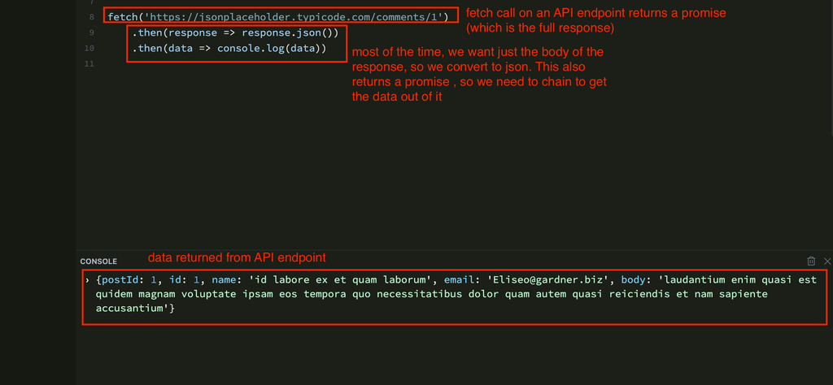

**Code Example 2: GET Request for a different dummy endpoint**

```python
%%script node

fetch('https://jsonplaceholder.typicode.com/todos/1')
    .then(response => response.json())
    .then(data => console.log(data))
```

```
{ userId: 1, id: 1, title: 'delectus aut autem', completed: false }
```

**Code Example 3: POST Request**

- For POST request, we need to include `method: "POST"` and include body we want to send POST request for.
- Here, in the body we included all for the key that were available when we receive in the GET request.

```python
%%script node

fetch('https://jsonplaceholder.typicode.com/todos/', {
    method: "POST",
    body: JSON.stringify({
        userId: 0,
        id: 1,
        title: 'do homework',
        completed: true
    })
})
    .then(response => response.json())
    .then(data => console.log(data))
```

```
{ id: 201 }
```

# 16. Async & Await

- By default, code is run top to bottom, synchronously.
- It will not wait for any line of code to finish running before running the next line.
- In some cases, this is not we want because we would want to wait for some piece of code to finish running before running the next.

**Example 1: Synchronous is the default**

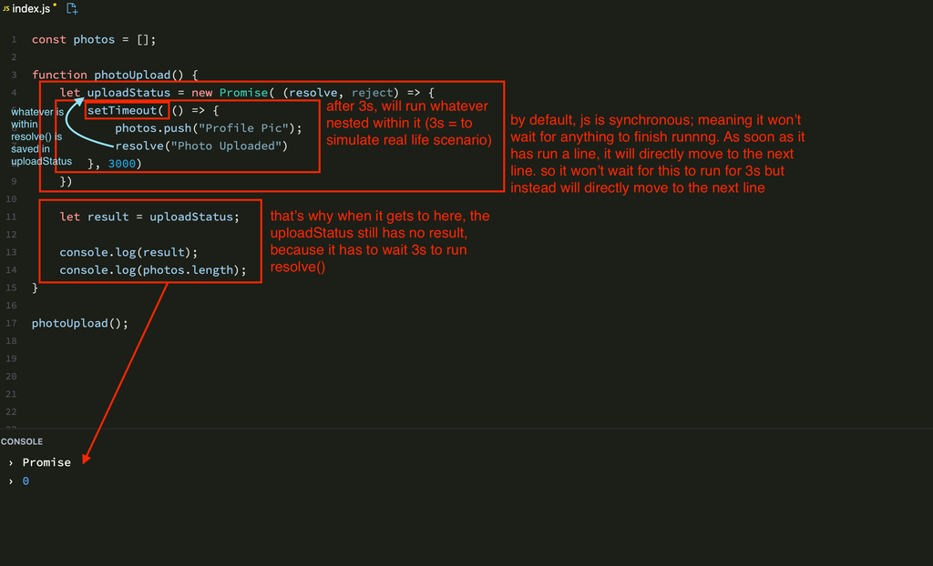

**Code Example 2: Asynchronous & await let us to wait for a piece of code to finish running before running the rest**

- We can turn a default synchronous function into a asynchronous by attaching `async` before the function definition.
- We also can put `await` in front of a piece of code we want to wait on, before running the rest.

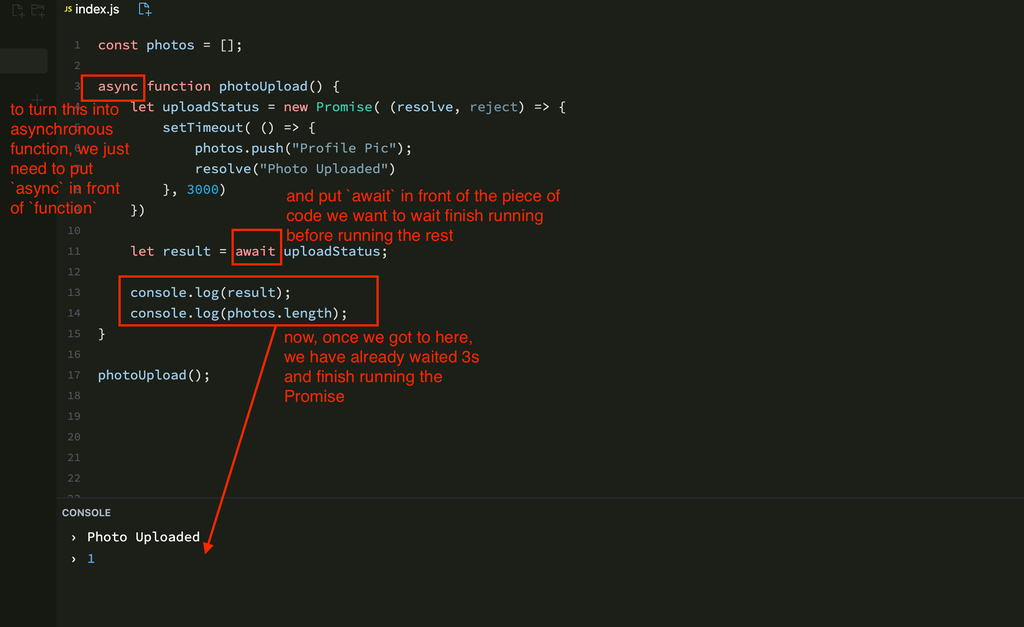

```python
%%script node

const apiUrl = "https://api.chucknorris.io/jokes/random";

async function getJoke() {
    const response = await fetch(apiUrl);
    const data = await response.json();
    const joke = data['value'];
    console.log(joke)

}

getJoke()
```

```
Chuck Norris can write two-handed.
```

# 17. Sets

- Same as python.

```python
%%script node

// create a new set
const a = new Set([1,
                    2,2,
                    3,3,3])

console.log(a)

// check if something is in the set
console.log(a.has(1))

// add to set
a.add(4).add(4).add(5)
console.log(a)

// get the length of the set using `size`, not `length`(they should just use 1 for all /meh)
console.log(a.size, a.length)

// clear the entire set
a.clear()
console.log(a.size)
```

```
Set(3) { 1, 2, 3 }
true
Set(5) { 1, 2, 3, 4, 5 }
5 undefined
0
```

# Credit

- The course: https://scrimba.com/introduction-to-es6-c0t